# Badanie zmienności rozkładu średniej arytmetycznej

## 5. Wizualizacja danych

### Wykresy gęstości

*Zestawienie wykresów gęstości w zależności od k* *dla danych z rozkładu Poissona z parametrem λ = 1 podniesionych do kwadratu*

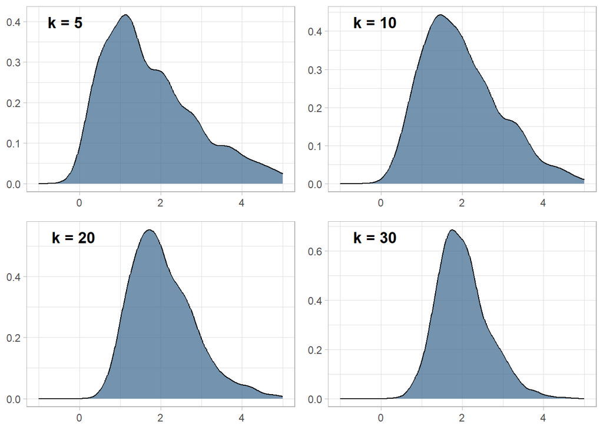

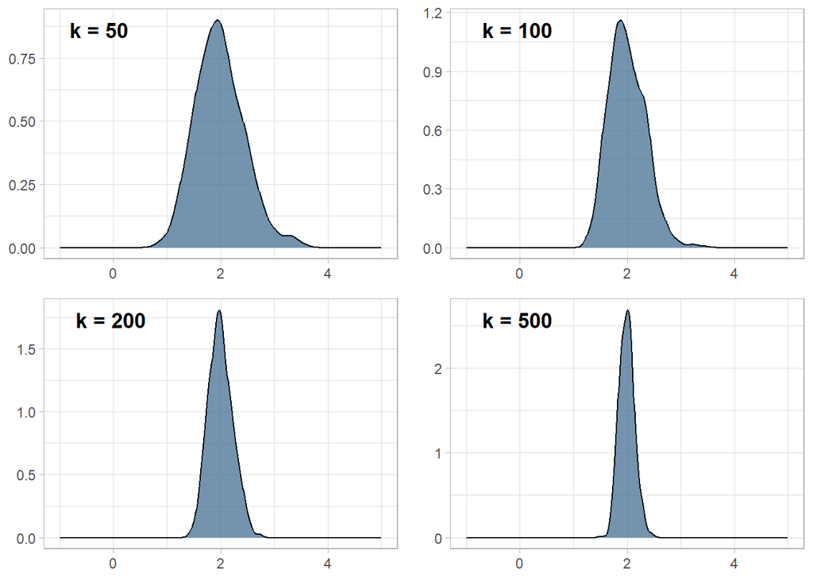

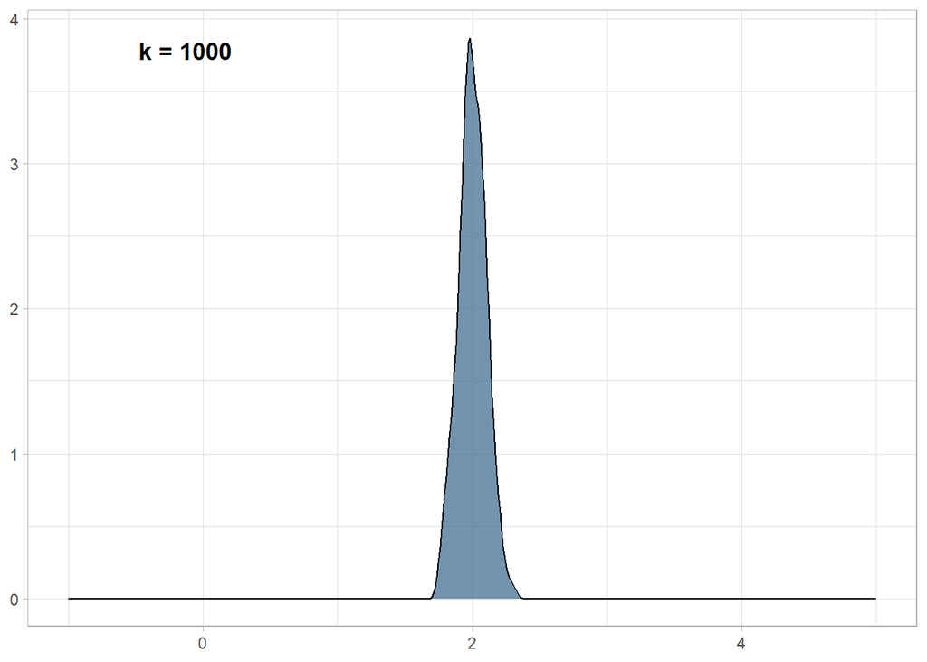

Na powyższych wykresach jednoznacznie widać zależność im większe k, tym krzywa gęstości jest bardziej “wysmukła” i skupiona wokół 2.

*Zestawienie wykresów gęstości w zależności od k* *dla danych z rozkładu Poissona z parametrem λ = 40 podniesionych do kwadratu*

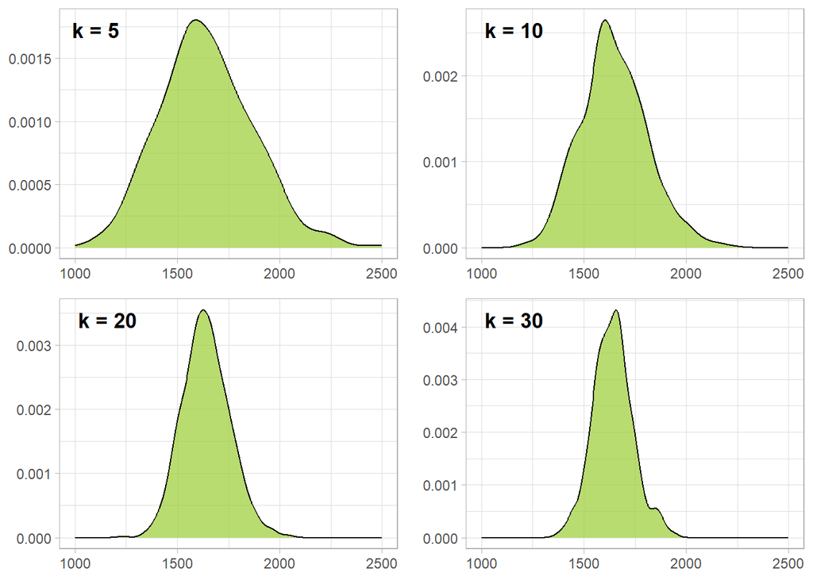

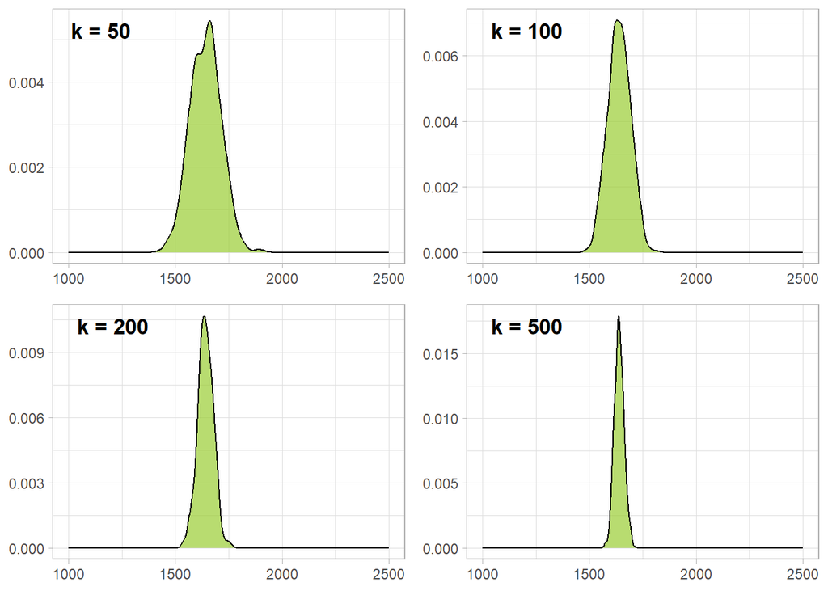

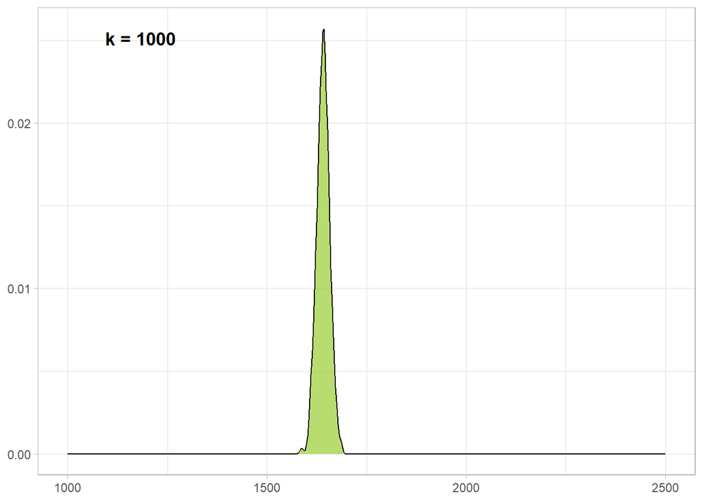

Ponownie można zauważyć zależność między wartościami k a kształtem krzywej gęstości.

### Wykresy pudełkowe

*Zestawienie wykresów pudełkowych w zależności od k* *dla danych z rozkładu Poissona z parametrem λ = 1 podniesionych do kwadratu*

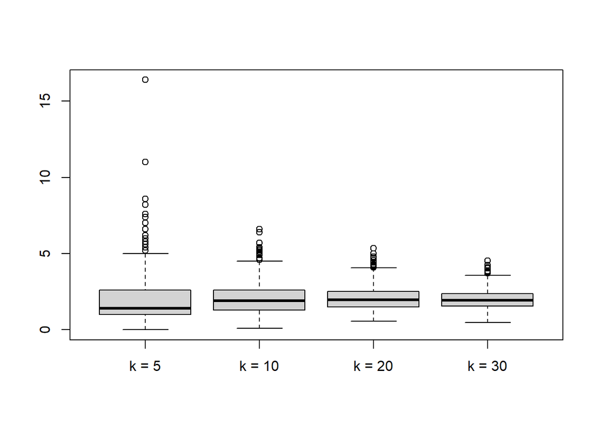

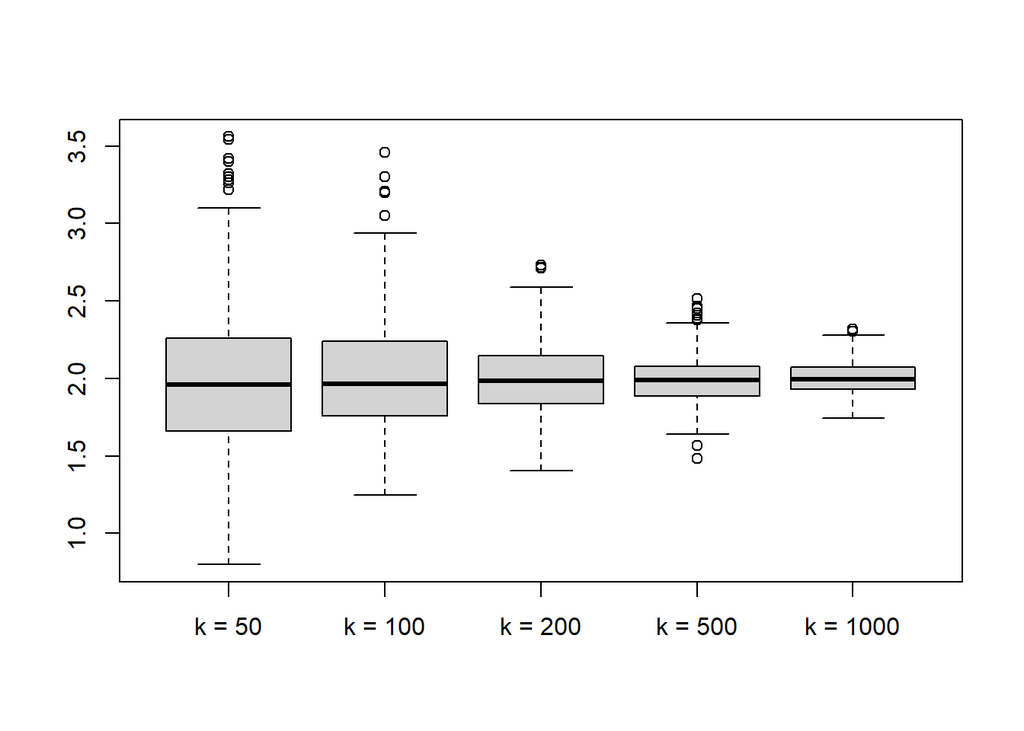

Na wykresach pudełkowych jeszcze lepiej widać zwężanie się rozkładu wraz ze wzrostem k. Proszę zwrócić uwagę na zmianę zakresu osi y między wykresami.

*Zestawienie wykresów pudełkowych w zależności od k* *dla danych z rozkładu Poissona z parametrem λ = 40 podniesionych do kwadratu*

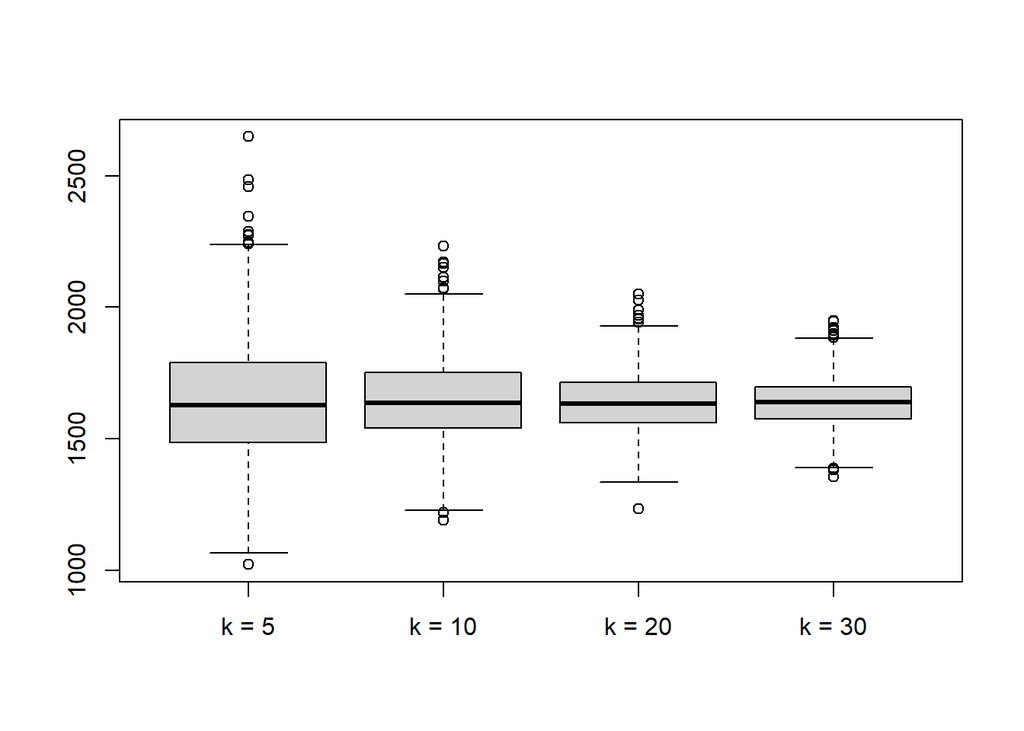

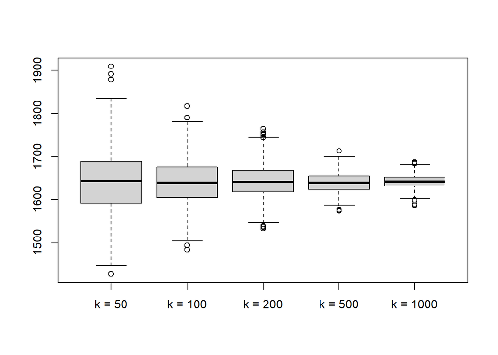

## 6. Badanie normalności rozkładu - test Shapiro-Wilka

Za pomocą testu Shapiro - Wilka dokonamy weryfikacji hipotezy o normalności badanego przez nas rozkładu.

**Hipoteza 0: Badany rozkład jest normalny**

**Hipoteza 1: Badany rozkład nie jest normalny**

poziom istotności α = 0.1

*Tabela 2.13. Wartości p-value dla testu Shapiro-Wilka przeprowadzonego na* *rozkładzie Poissona z parametrem λ = 1, dla konkretnych k:*

| 5 | 10 | 20 | 30 | 50 | 100 | 200 | 500 | 1000 |
| --- | --- | --- | --- | --- | --- | --- | --- | --- |
| 0 | 0 | 0 | 0 | 0 | 0 | 0.003 | 0.016 | 0.218 |

Wizualizacja wyników dla parametru λ = 1.

Czarna linia na wykresie reprezentuje poziom istotności α = 0.1.

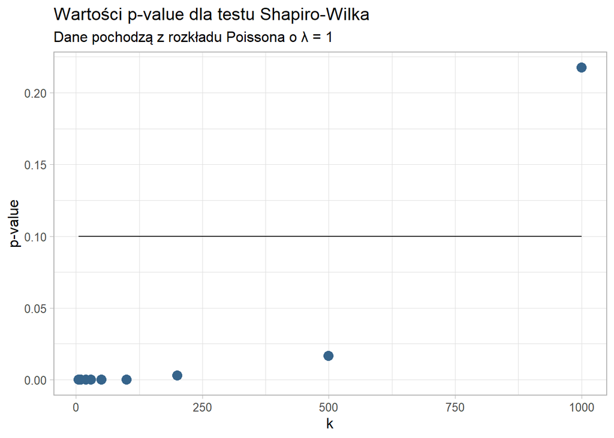

*Tabela 2.14. Wartości p-value dla testu Shapiro-Wilka przeprowadzonego na* *rozkładzie Poissona z parametrem λ = 40, dla konkretnych k:*

| 5 | 10 | 20 | 30 | 50 | 100 | 200 | 500 | 1000 |
| --- | --- | --- | --- | --- | --- | --- | --- | --- |
| 0 | 0.001 | 0.078 | 0.004 | 0.446 | 0.722 | 0.577 | 0.331 | 0.544 |

Wizualizacja wyników dla parametru λ = 40.

Nie można zatem stwierdzić występowania zależności: im większe k, tym większa wartość p-value.

[figure not shown]

### Podsumowanie

W poniższych tabelach zamieszczone zostały zestawienia podstawowych charakterystyk rozkładu w zależności od liczby danych wykorzystanych do obliczenia średniej (k).

*Tabela 2.15. Zestawienie podstawowych statystyk w zależności od k* *dla danych z rozkładu Poissona z parametrem λ = 1 podniesionych do kwadratu*

|  | 5 | 10 | 20 | 30 | 50 | 100 | 200 | 500 | 1000 |
| --- | --- | --- | --- | --- | --- | --- | --- | --- | --- |
| średnia | 1.937 | 2.021 | 2.061 | 2.013 | 1.983 | 2.000 | 1.996 | 1.991 | 2.000 |
| odch_stand | 1.531 | 1.024 | 0.788 | 0.621 | 0.458 | 0.340 | 0.226 | 0.145 | 0.103 |
| skośność | 2.393 | 0.951 | 0.854 | 0.645 | 0.435 | 0.508 | 0.268 | 0.246 | 0.067 |
| kurtoza | 15.442 | 4.080 | 3.831 | 3.522 | 3.323 | 3.422 | 2.875 | 3.235 | 2.868 |

*Tabela 2.16. Zestawienie podstawowych statystyk w zależności od k* *dla danych z rozkładu Poissona z parametrem λ = 40 podniesionych do kwadratu*

|  | 5 | 10 | 20 | 30 | 50 | 100 | 200 | 500 | 1000 |
| --- | --- | --- | --- | --- | --- | --- | --- | --- | --- |
| średnia | 1642.984 | 1646.321 | 1639.280 | 1640.852 | 1641.423 | 1639.453 | 1641.233 | 1639.051 | 1640.879 |
| odch_stand | 231.456 | 163.320 | 115.296 | 96.570 | 72.059 | 52.663 | 36.857 | 22.787 | 15.824 |
| skośność | 0.398 | 0.308 | 0.217 | 0.213 | 0.084 | 0.017 | 0.034 | 0.116 | -0.040 |
| kurtoza | 3.464 | 3.214 | 3.241 | 3.280 | 3.099 | 2.758 | 3.128 | 2.967 | 3.150 |

Wnioski: